# Graph 1997m6-2001m12

Emi

10/02/2021

## Loading data

Load the database from Stata:

```r
dbRelations <- read_dta('./data/interLoans/cen_deu_1997-06_2001-06_todas_ent_fcieras.dta') %>%
              dplyr::select(., FECHAdata, IDENT_ACREEDORA, IDENT_DEUDORA,           PRESTAMOS) %>%
              dplyr::filter(., !is.na(IDENT_DEUDORA)) %>%
              dplyr::mutate(., FECHAdata = ymd("1960-01-01")+months(FECHAdata))
dbFcialEnts <- read_dta('./data/DBbanks/capital-allEntities-Monthly.dta', col_select = c(IDent, FECHAdata, bNombre, grupoIDUni, Activo, ActivoR,
                      ALIQs1_1ratio, APRamplio, C8Est_w, CAR_IRR_3A6,
                      P_LOANS_ARS_RATE, P_DEP_ARS_RATE, P_ROA, C8_E)) %>%
                dplyr::mutate(., FECHAdata = ymd("1960-01-01")+months(FECHAdata),                        IDENT_ACREEDORA = IDent) %>%
                filter(., FECHAdata<ymd("2002-01-01") & FECHAdata>ymd("1997-05-01"))
```

### Weighting relations

Now we build the wights of each link. We backup the data on Assets and Loans from dbFcialEnts and enter into the dbRelations data frame.

```r
relations <- dbRelations %>%
              filter(., IDENT_ACREEDORA != IDENT_DEUDORA) %>%
              dplyr::left_join(., dbFcialEnts, by = c('IDENT_ACREEDORA', 'FECHAdata'))
```

## Oh missing values!

### From creditors perspective

The following entities appear in the Central de deudores but not anymore in the balance de saldos:

```r
missCreditors <- dplyr::anti_join(relations, dbFcialEnts,
                                  by=c('FECHAdata', 'IDENT_ACREEDORA'))
```

The **318 Banco de Salta SA** which was absorbed by Banco Macro on November 1999. I have detailed data only till Sep-1999. I could get more aggregated data if necesary from the balance resumido. **Caja de crédito Universo Cooperativa Limitada 64123** did not report its balance in 2000-10. I treat it as a missing value.

I impute this missing values. Replace with the previous value

```r
toAddSalta <- filter(dbFcialEnts, FECHAdata == ym(199909) &IDent == 318) %>%
            mutate(., FECHAdata = ym(199910))
toAddUniverso <- filter(dbFcialEnts, FECHAdata == ym(200009) &IDent == 64123) %>%
                  mutate(., FECHAdata = ym(200010))
dbFcialEnts <- bind_rows(dbFcialEnts, toAddSalta, toAddUniverso)
```

### From debtors perspective

Verify that all nodes involved in relations are in dbFcialEnts. The following table shows the relations in which a debtor does not appear in dbFcialEnts. *anti_join()*, returns rows in *relations* without a match in *dbFcialEnts*.

```r
missDebtors <- anti_join(relations,
                    mutate(dbFcialEnts, IDENT_DEUDORA = IDent),
                    by=c('FECHAdata', 'IDENT_DEUDORA')) %>%
                  group_by(., IDENT_DEUDORA) %>%
                  summarise(n = n())
missDebtors
```

```
## # A tibble: 50 x 2
##    IDENT_DEUDORA     n
##            <dbl> <int>
##  1             1   108
##  2             6    72
##  3            12    54
##  4            25    22
##  5            39    10
##  6            49    18
##  7            50     1
##  8            54     1
##  9            56    16
## 10            61    26
## # ... with 40 more rows
```

This could be due to debtors disappearing. A debtor disappears as a financial entitites but the debts do not expire, such that active financial entities still report the debts.

I exclude these relations from the *relations* tibble. We exclude those observations and select a specific month, say, 1999m12

```r
#relations <- filter(relations, !is.na(IDent))
atDate <- ymd("1999-12-01")
thisRelations <- dplyr::filter(relations, FECHAdata == atDate) %$%
                  .[ !(.$IDENT_DEUDORA %in% missDebtors$IDENT_DEUDORA),  ] %>%
                  dplyr::mutate(., WEIGHT = PRESTAMOS/APRamplio) %>%
                  dplyr::select(., IDENT_ACREEDORA, IDENT_DEUDORA, WEIGHT)
nodes <- filter(dbFcialEnts, FECHAdata==atDate) %>%
          dplyr::select(., !FECHAdata)
```

When did these bank end in ‘entidades.dta’?

```r
dbEnts <- read_dta('../BasesBCRA-IEF/entidades/entidades.dta') %>%
          dplyr::mutate(., FECHAdata = ymd("1960-01-01")+months(FECHAdata))
entsDates <- dbEnts %>%
              group_by(., IDent) %>%
              summarise(firstDate = min(FECHAdata), endDate = max(FECHAdata))
#save2Excel(entsDates, 'entsDates',  'entsDates.xlsx')
entsDates
```

[output not shown]

```r
g <- graph_from_data_frame(thisRelations, directed = TRUE,
                           vertices = nodes)
```

Acces a specific node (vertix):

```r
V(g)[[1]]
```

```
## + 1/116 vertex, named, from d4e2edc:
##   name     bNombre grupoIDUni Activo ActivoR ALIQs1_1ratio  C8Est_w CAR_IRR_3A6
## 1    3 B.E.A.L. SA          6 950233 2115945      2.209142 10.88607           0
##   P_LOANS_ARS_RATE P_DEP_ARS_RATE P_ROA C8_E APRamplio IDENT_ACREEDORA
## 1            13.77          13.92  1.51   NA    844055               3
```

gives all the details about the first vertix.

We can plot g

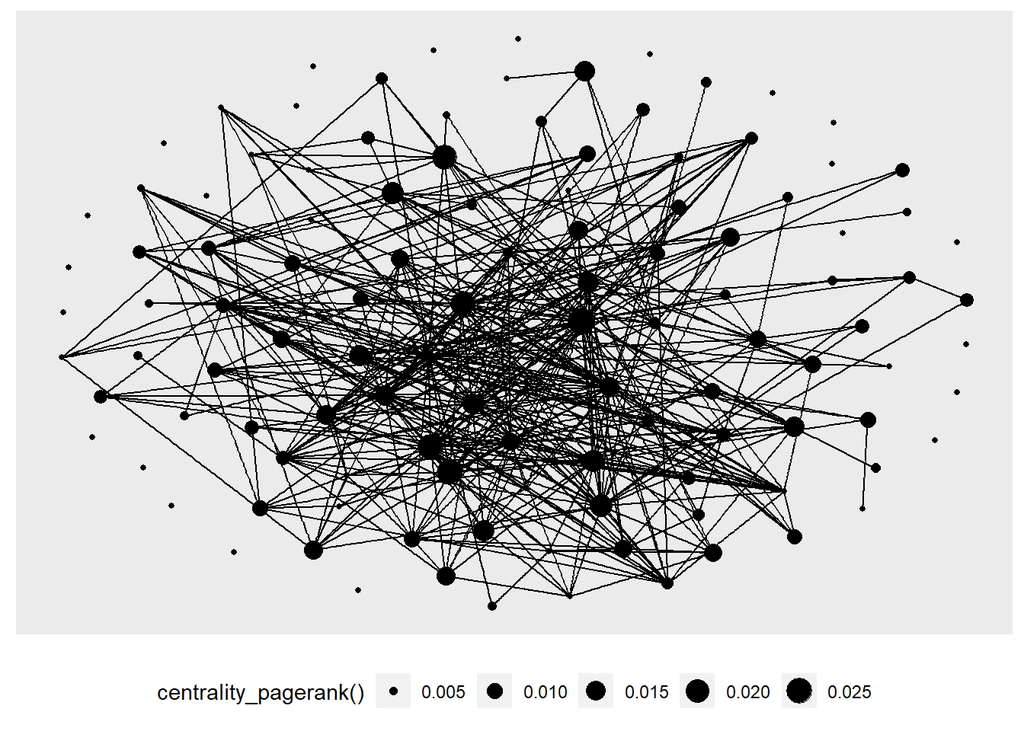

```r
library(ggraph)
ggraph(g, layout='fr', weights=WEIGHT ) +
  geom_edge_link() +
  geom_node_point(aes(size = centrality_pagerank())) +
  theme(legend.position = 'bottom')
```

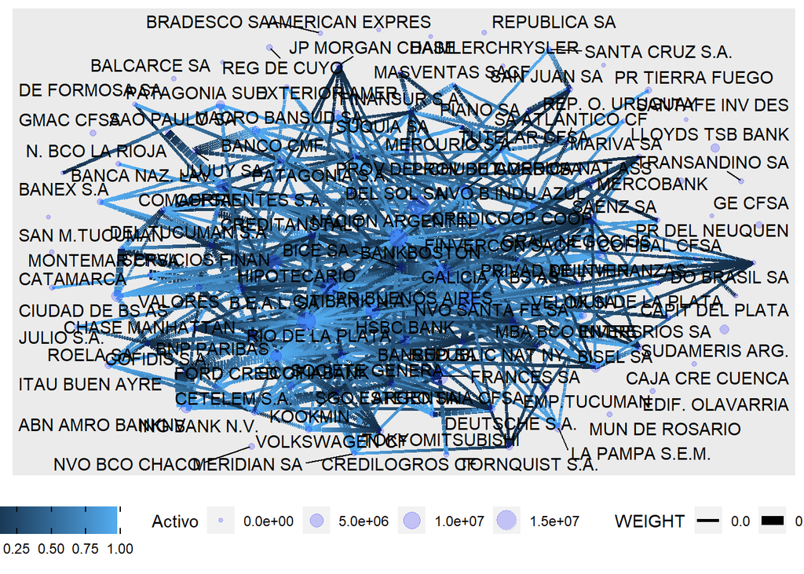

```r
ggraph(g, layout='fr', weights=WEIGHT ) +
  geom_edge_link(aes(width=WEIGHT, colour=stat(index))) +
  geom_node_point(aes(size = Activo), colour='blue', alpha=.2) +
  geom_node_text(aes(label = bNombre), repel=TRUE) +
  theme(legend.position = 'bottom')
```

## Interactive plot Using visNetwork package. I use the same ‘g’ object from iGraph

```r
pTblNodes <- nodes %>%
  dplyr::select(., IDent, bNombre, Activo) %>%
  dplyr::transmute(., id=IDent, label=bNombre, value=Activo, title=str_c(bNombre, ', $ ', (Activo/10000), ' mill.'))

pTblRelations <- thisRelations %>%
  dplyr::transmute(., from=IDENT_ACREEDORA, to=IDENT_DEUDORA, value=WEIGHT, arrows='to')

visNetwork(nodes = pTblNodes, edges = pTblRelations)%>%
  visOptions(highlightNearest = TRUE, nodesIdSelection = TRUE) %>%
  visInteraction(navigationButtons = TRUE) %>%
  visConfigure(enabled = TRUE)
```

[interactive chart not shown]

```r
#%>%
#  visNodes(scaling=list())



#visIgraph(g) %>%
#  visNodes(shape='square', size = WEIGHT)
```